# An Overview of Artisan Chocolates

# Introduction

This is a simple project that I wanted to perform in order to reinforce the skills I am learning within R, and to create reference code for possible future events; in addition, this is meant to reinforce, develop, and increase the efficacy of my coding habits in order to output clean, readible code in a prompt manner. The dataset here has been provided by [Flavors of Cacao](http://flavorsofcacao.com/index.html), it is a website where they discuss craft chocolates and provide general information about chocolate and information to help small chocolatiers become successful. It is a very helpful site in regards to a person who wishes to expand their knowledge of chocolates or to a novice connoisseur. The dataset is posted on the website and it contains 10 variables regarding the chocolate bars:

1. Ref: The reference number of the review
2. Company: The name of the company which produced the bar
3. Company Location: The country the company is based
4. Review Date: The year in which the chocolate bar was reviewed
5. Country of Bean Origin: The origin country of the cacoa used for the chocolate
6. Specific Bean Origin or Bar Name: This variable will be omitted from the analysis
7. Cocoa Percent: The “darkness” of the cocoa
8. Ingredients: The list of ingredients used in the chocolate (B = Beans, S = Sugar, S* = Sweetener other than white cane or beet sugar, C = Cocoa Butter, V = Vanilla, L = Lecithin, Sa = Salt)
9. Most Memorable Characteristics: Memorable flavors of the chocolate
10. Rating: The score given to the chocolate from 1 to 5, [further information on the review guide](http://flavorsofcacao.com/review_guide.html)

## Questions

As I explore and analyze this dataset, I hope to answer the following questions:

- What beans, companies, countries and or manufacturers produce the highest rated chocolate bars?
- What makes a chocolate bar high quality?
- What are the ratings of the bars by unique characteristics?
- Can this information be used to predict which chocolate bars will be awarded the highest ratings?

# Data Cleaning

```r
# Observing Structure of the dataset
str(Chocolate)
head(Chocolate)
names(Chocolate)

# Changing Column Names
colnames(Chocolate) <- str_remove_all(names(Chocolate), " ")
colnames(Chocolate)[colnames(Chocolate) == "Company(Manufacturer)"] <- "Manufacturer"


# Changing Cocoa Percent into a numeric fraction
Chocolate$CocoaPercent <- as.numeric(str_remove_all(Chocolate$CocoaPercent, "%"))/100
Chocolate$CompanyLocation <- str_remove_all(Chocolate$CompanyLocation, '\\.')

# Adding Missing Values
Chocolate$Ingredients[Chocolate$Ingredients == ""] <- NA_character_

# Counting the number of unique values for Company Location and Manufacturer
length(unique(Chocolate$Manufacturer))
length(unique(Chocolate$CompanyLocation))
length(unique(Chocolate$CountryofBeanOrigin))
length(unique(Chocolate$SpecificBeanOriginorBarName))

# Counting number of missing observations by column
sapply(Chocolate, FUN = function(x){sum(is.na(x))})

# Chocolate 2: Separating conjoined variables
Chocolate2 <- Chocolate %>%
  separate(Ingredients, into = c("No.Ingredients","Ingredients"), sep = "(- )|(-)") %>%
  mutate(Bean = str_detect(Ingredients,"B"),
         Sugar = ifelse(str_detect(Ingredients, "S") == TRUE & str_detect(Ingredients, fixed("S*")) == FALSE, TRUE, FALSE),
         Sweetener = str_detect(Ingredients, fixed("S*")),
         CocoaButter = str_detect(Ingredients, "C"),
         Vanilla = str_detect(Ingredients, "V"),
         Lecithin = str_detect(Ingredients, "L"),
         Salt = str_detect(Ingredients, "Sa")
         )
temptemp <- Chocolate2[Chocolate2$Salt == T & Chocolate2$Sugar == T]

#   separate(MostMemorableCharacteristics, into = c("Char1", "Char2","Char3","Char4"), sep = ",", fill = 'right')
#
# Chocolate$MostMemorableCharacteristics <- strsplit(Chocolate$MostMemorableCharacteristics, ",")
# str(Chocolate)

datatable(
  Chocolate
)
```

This dataset is relatively clean with few missing values, `sapply(Chocolate, FUN = function(x){sum(is.na(x))})`: the missing values are concentrated in one variable labelled ingredients. From the original data, only standard data cleaning precedures were implemented, including but not limited to altering variable names, altering strings for consistency, and separating variables.

The separation of the variables ingredients and the most memorable qualities of the chocolate was the most intricate part of the cleaning process. This dataframe was saved into a separate dataset in order to conduct further research.

# Setion 1: An Examination by Bean Origin, Country, and Company

## Companies with the highest Average Rating

### A table of the Companies with the highest average rating

```r
# Exploratory Data Analysis
# Which Manufacturer Produces the best Chocolates
datatable(
  ByComp <- Chocolate %>%
  group_by(Manufacturer, CompanyLocation) %>%
  summarize(AvgRating = round(mean(Rating), 2),
            BarsReviewed = n()) %>%
  arrange(desc(AvgRating))
  )
```

|  | Manufacturer | CompanyLocation | AvgRating | BarsReviewed |
| --- | --- | --- | --- | --- |
| 1 | Tobago Estate (Pralus) | France | 4 | 1 |
| 2 | Heirloom Cacao Preservation (Zokoko) | U.S.A. | 3.88 | 2 |
| 3 | Ocelot | Scotland | 3.88 | 2 |
| 4 | Matale | Australia | 3.81 | 4 |
| 5 | Patric | U.S.A. | 3.79 | 6 |
| 6 | Idilio (Felchlin) | Switzerland | 3.78 | 10 |
| 7 | Chocola'te | U.S.A. | 3.75 | 2 |
| 8 | Christopher Morel (Felchlin) | Canada | 3.75 | 1 |
| 9 | Dole (Guittard) | U.S.A. | 3.75 | 1 |
| 10 | Kerchner | U.S.A. | 3.75 | 1 |

[output cut: 536 more lines]

The table presented above can be sorted based on the columns; in addition, specific values can be searched for in the search box. Both of these tools can be used to specify a search to a specific country, manufacturer, score, or the quantity of bars reviewed.

### A graph of the average ratings by company

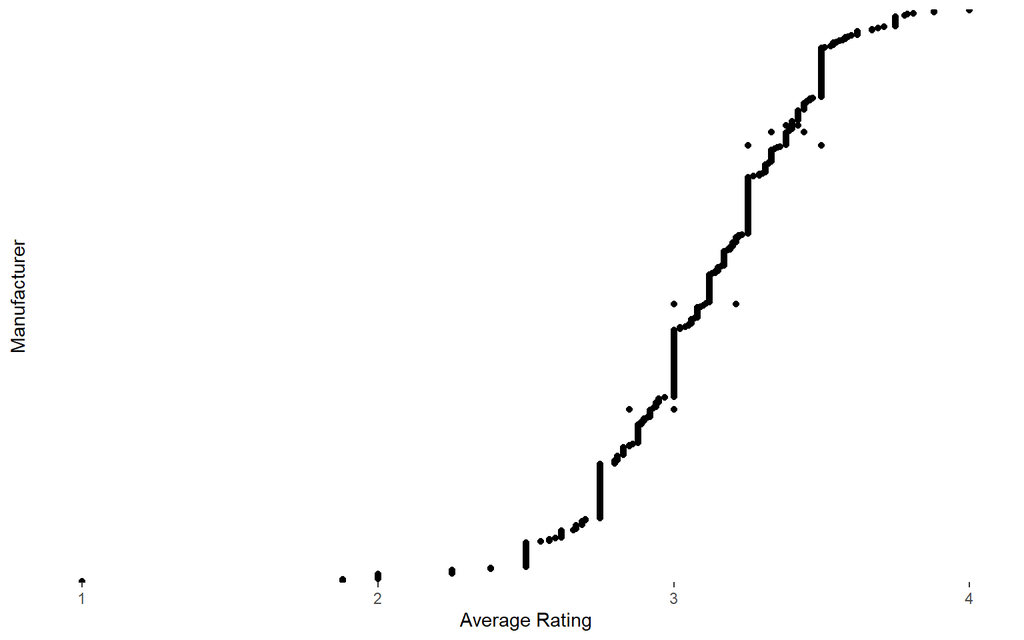

```r
# Visualization of top companies for companies with the highest quantity of bars reviewed
ByComp %>%
  ggplot(aes(x = fct_reorder(Manufacturer, AvgRating), y = AvgRating)) +
  geom_point() +
  coord_flip() +
  theme(
    axis.text.y = element_blank(),
    axis.ticks.y = element_blank()
  ) +
  labs(y = "Average Rating",
      x = "Manufacturer")
```

Based on the graph presented above, there is a significant amount of companies who have an average score around 3. The scores appear to be a sigmoid as there are bounds to this dataset; however, the upper bound of the score theoretically is 5, but the graphic above shows that realistically, the limit appears to be 4 as that is the highest rating ever achieved by any chocolate bar, specifically 102.

Moreover, the companies which appear to have an average rating at the realistic bounds of 1 and 4 appear to have have less or 1 bar which has been reviewed. This is information that can be seen in the table as well.

### A graph of the companies with the highest amount of bars reviewed

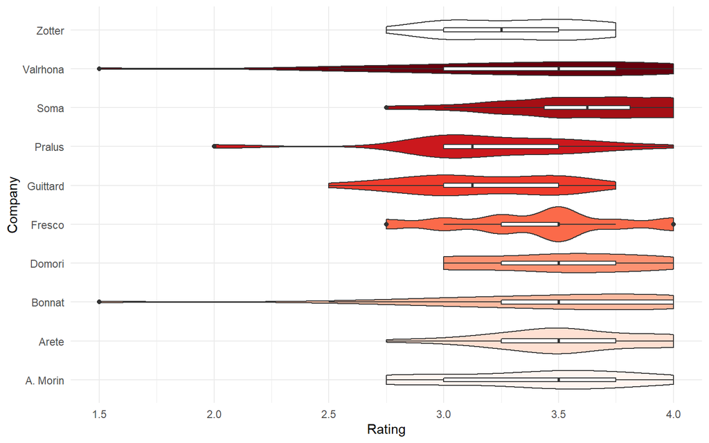

```r
topComp <- ByComp %>%
  arrange(desc(BarsReviewed))

Chocolate[Chocolate$Manufacturer %in% topComp$Manufacturer[1:10]] %>%
  ggplot(aes(x = Manufacturer, y = Rating)) +
  geom_violin(aes(fill = Manufacturer)) +
  scale_fill_brewer(palette = 'Reds') +
  geom_boxplot(width = 0.1) +
  theme_minimal() +
  coord_flip() +
  theme(legend.position="none") +
  labs(x = "Company",
       y = "Rating")
```

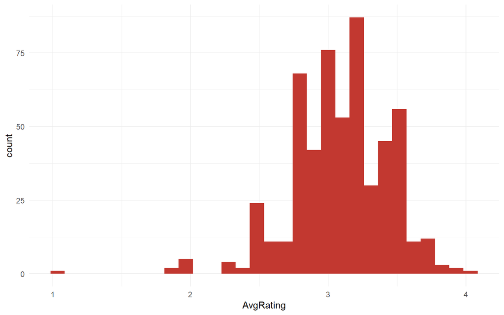

```r
ggplot(ByComp, aes(AvgRating)) +
  geom_histogram(fill = '#c23830') +
  theme_minimal()
```

## Countries with the highest average rating

### A table of the Countries with the highest average rating

```r
# Exploratory Data analysis
# Which country produced the best chocolates
datatable(
ChocByCountry  <- Chocolate %>%
  group_by(CompanyLocation) %>%
  summarize(AvgRating = round(mean(Rating), 2),
            BarsReviewed = n()) %>%
  arrange(desc(AvgRating))
  )
```

|  | CompanyLocation | AvgRating | BarsReviewed |
| --- | --- | --- | --- |
| 1 | Chile | 3.75 | 2 |
| 2 | UAE | 3.4 | 5 |
| 3 | Poland | 3.38 | 8 |
| 4 | Australia | 3.36 | 53 |
| 5 | Guatemala | 3.35 | 10 |
| 6 | Denmark | 3.34 | 31 |
| 7 | Norway | 3.33 | 3 |
| 8 | Scotland | 3.33 | 10 |
| 9 | Vietnam | 3.33 | 15 |
| 10 | Amsterdam | 3.31 | 12 |

[output cut: 57 more lines]

### Graphical Representations of Countries with the Most Bars Reviewed

#### Ordered Scatter Plot

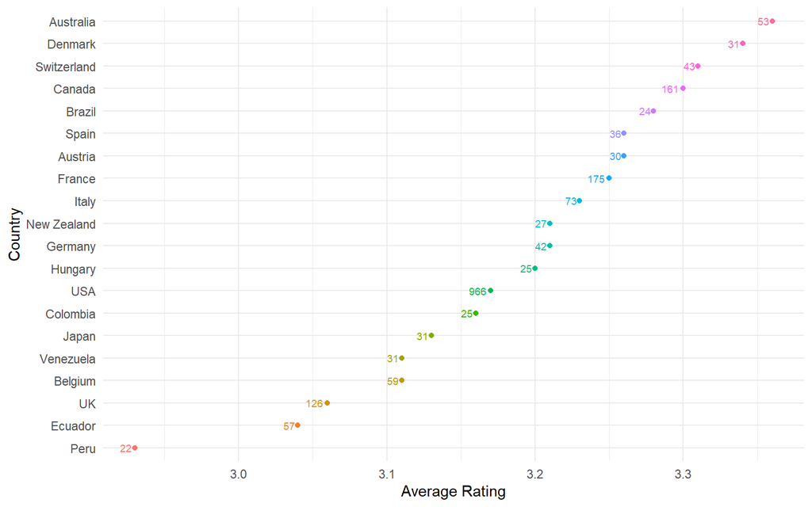

```r
# Visualization
ChocByCountry$CompanyLocation <- factor(ChocByCountry$CompanyLocation, levels = ChocByCountry$CompanyLocation[order(ChocByCountry$AvgRating)])

# Ordered Scatter Plot
ggplot(top_n(ChocByCountry, 20), aes(CompanyLocation, AvgRating, color = CompanyLocation)) +
  geom_point() +
  coord_flip() +
  theme_minimal() +
  theme(
    legend.position = 'none'
  ) +
  geom_text(aes(x = CompanyLocation,
                y = AvgRating,
                label = BarsReviewed),
                hjust = 1.25,
                size = 2.5) +
    labs(x = "Country",
       y = "Average Rating")
```

#### Violin Plot

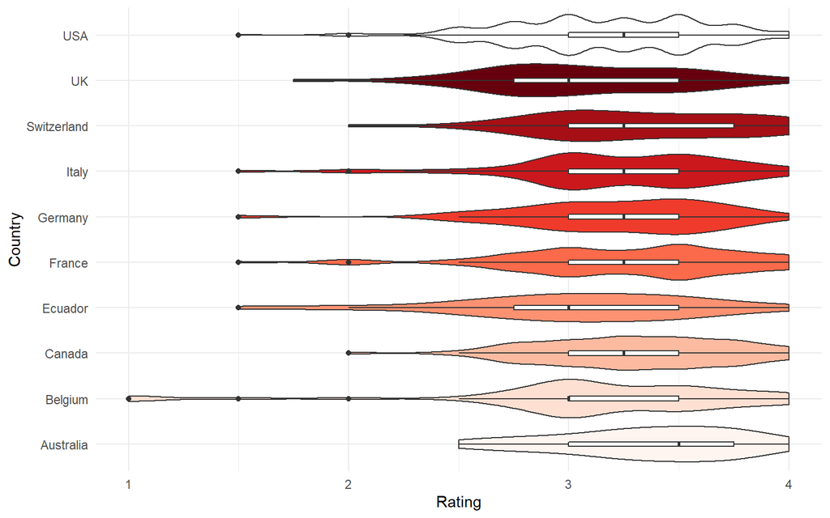

```r
# Violin Plots
Countries <- top_n(ChocByCountry, 10)$CompanyLocation
ggplot(Chocolate[which(CompanyLocation %in% Countries)], aes(x = CompanyLocation, y = Rating)) +
  geom_violin(aes(fill = CompanyLocation)) +
  scale_fill_brewer(palette = 'Reds') +
  geom_boxplot(width = 0.1) +
  theme_minimal() +
  coord_flip() +
  theme(legend.position="none") +
  labs(x = "Country",
       y = "Rating")
```

The graphs above have been limited to the countries with the highest amount of bars rated due to the fact that there is a significant amount of countries who obtain a top position with few bars reviewed.

## Bean Origin with the highest average rating

### A table of the bean origin with the highest average rating

```r
# Exploratory Data analysis
# Which country produced the best chocolates
datatable(
ByOrigin  <- Chocolate %>%
  group_by(CountryofBeanOrigin) %>%
  summarize(AvgRating = round(mean(Rating), 2),
            BarsReviewed = n()) %>%
  arrange(desc(AvgRating))
  )
```

|  | CountryofBeanOrigin | AvgRating | BarsReviewed |
| --- | --- | --- | --- |
| 1 | Tobago | 3.62 | 2 |
| 2 | Sao Tome &amp; Principe | 3.5 | 1 |
| 3 | Solomon Islands | 3.45 | 10 |
| 4 | Congo | 3.32 | 11 |
| 5 | Thailand | 3.3 | 5 |
| 6 | Cuba | 3.29 | 12 |
| 7 | Guatemala | 3.27 | 53 |
| 8 | Haiti | 3.27 | 24 |
| 9 | Papua New Guinea | 3.27 | 49 |
| 10 | Madagascar | 3.26 | 163 |

[output cut: 53 more lines]

### Graphical Representations of Bean Origins the Most Bars Reviewed

#### Ordered Scatter Plot

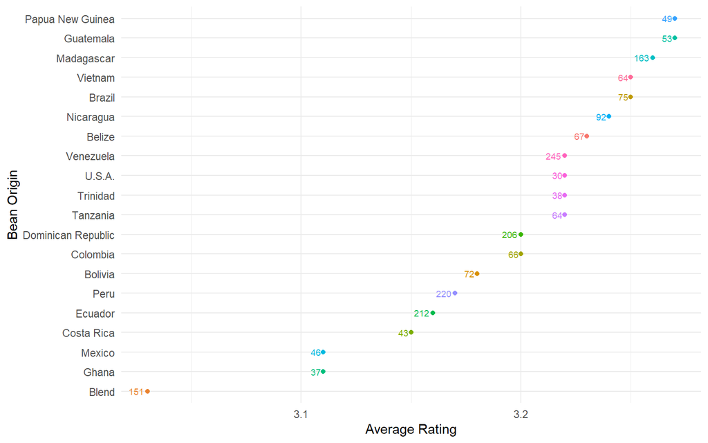

```r
# Visualization
# Ordered Scatter Plot
ggplot(top_n(ByOrigin, 20), aes(fct_reorder(CountryofBeanOrigin, AvgRating), AvgRating, color = CountryofBeanOrigin)) +
  geom_point() +
  coord_flip() +
  theme_minimal() +
  theme(
    legend.position = 'none'
  ) +
  geom_text(aes(x = CountryofBeanOrigin,
                y = AvgRating,
                label = BarsReviewed),
                hjust = 1.25,
                size = 2.5) +
    labs(x = "Bean Origin",
       y = "Average Rating")
```

#### Violin Plot

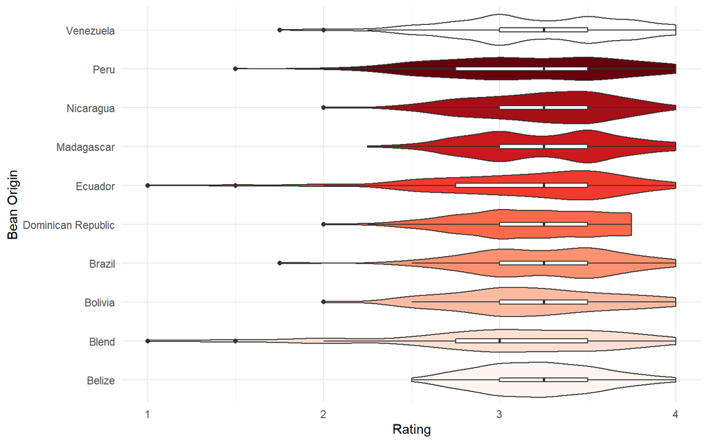

```r
# Violin Plots
Origin <- top_n(ByOrigin, 10)$CountryofBeanOrigin
ggplot(Chocolate[which(CountryofBeanOrigin %in% Origin)], aes(x = CountryofBeanOrigin, y = Rating)) +
  geom_violin(aes(fill = CountryofBeanOrigin)) +
  scale_fill_brewer(palette = 'Reds') +
  geom_boxplot(width = 0.1) +
  theme_minimal() +
  coord_flip() +
  theme(legend.position="none") +
  labs(x = "Bean Origin",
       y = "Rating")
```

## Summary

### Company

In this section, not much can be said about which companies are better in an absolute manner because each most companies have a different quantity of chocolate bars reviewed. In order to correctly account for the difference in the number of bars reviewed, there should be mathematically weighted.

### Company Location

Once again, the data faces the same problem, there is not enough reviewed bars for some countries, and so countries with too few reviews cannot be accurately compared against countries which have a large number of bars reviewed.

### Bean Origin

The country of origin for the bean does not make much of a difference when it comes to the rating of the chocolate bars because most of the beans from the specified origins are relatively close to the mean rating of the chocolate bars.

```r
Choc_test <- tidy(t.test(Chocolate$Rating, Chocolate$Rating[Chocolate$CountryofBeanOrigin == "Ghana"]))
colnames(Choc_test) <- c("estimate", "estimate1", "estimate2", "statistic", "p.value", "parameter", "conf.low", "conf.high", "method", "alternative")

for(i in 1:nrow(ByOrigin)){
  temp0 <- unique(Chocolate$CountryofBeanOrigin)
  co_r <- Chocolate$Rating[Chocolate$CountryofBeanOrigin == temp0[i]]
  if(length(co_r) > 15){
  Choc_test[i,] <- tidy(t.test(Chocolate$Rating, co_r))}
  else{
  co_r2 <- mean(co_r)
  Choc_test[i,] <- cbind(tidy(t.test(Chocolate$Rating, mu = co_r2)), estimate1 = NA, estimate2 = NA)[, c(1, 9, 10, 2, 3, 4, 5, 6, 7, 8)]}
}
Choc_test <- cbind(temp0,Choc_test)
Choc_test[, c(2,3,4,5,6,7,8,9)]  <- round(Choc_test[, c(2,3,4,5,6,7,8,9)],3)
datatable(Choc_test)
```

|  | temp0 | estimate | estimate1 | estimate2 | statistic | p.value | parameter | conf.low | conf.high | method | alternative |
| --- | --- | --- | --- | --- | --- | --- | --- | --- | --- | --- | --- |
| 1 | Ghana | 0.069 | 3.184 | 3.115 | 0.768 | 0.447 | 36.796 | -0.113 | 0.252 | Welch Two Sample t-test | two.sided |
| 2 | Sao Tome | 3.184 |  |  | 11.985 | 0 | 2311 | 3.166 | 3.203 | One Sample t-test | two.sided |
| 3 | Blend | 0.149 | 3.184 | 3.035 | 2.793 | 0.006 | 159.709 | 0.044 | 0.255 | Welch Two Sample t-test | two.sided |
| 4 | Colombia | -0.02 | 3.184 | 3.205 | -0.377 | 0.707 | 69.087 | -0.129 | 0.088 | Welch Two Sample t-test | two.sided |
| 5 | Dominican Republic | -0.018 | 3.184 | 3.202 | -0.623 | 0.534 | 256.97 | -0.074 | 0.039 | Welch Two Sample t-test | two.sided |
| 6 | Madagascar | -0.077 | 3.184 | 3.261 | -2.375 | 0.019 | 193.309 | -0.14 | -0.013 | Welch Two Sample t-test | two.sided |
| 7 | Papua New Guinea | -0.086 | 3.184 | 3.27 | -1.562 | 0.125 | 50.9 | -0.197 | 0.025 | Welch Two Sample t-test | two.sided |
| 8 | Venezuela | -0.04 | 3.184 | 3.224 | -1.299 | 0.195 | 295.22 | -0.102 | 0.021 | Welch Two Sample t-test | two.sided |
| 9 | U.S.A. | -0.033 | 3.184 | 3.217 | -0.399 | 0.693 | 29.785 | -0.199 | 0.134 | Welch Two Sample t-test | two.sided |
| 10 | Jamaica | 0.01 | 3.184 | 3.174 | 0.105 | 0.917 | 22.422 | -0.19 | 0.21 | Welch Two Sample t-test | two.sided |

[output cut: 53 more lines]

# Section 2: Analysis of Cocoa concentration on Rating

## Statistics of Ratings and Cocoa Percent

### Examining the Distribution of Ratings

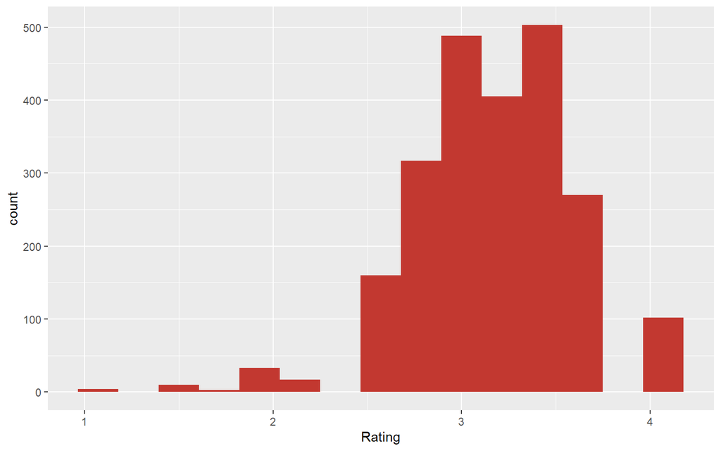

```r
ggplot(Chocolate, aes(Rating)) +
  geom_histogram(bins = 15,
                 fill = "#c23830")
```

### Examining the Distribution of Cocoa Percent

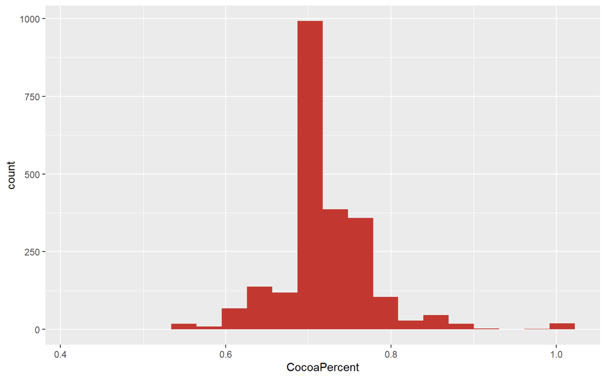

```r
ggplot(Chocolate, aes(CocoaPercent)) +
  geom_histogram(bins = 20,
                 fill = "#c23830")
```

### Polynomial Regression Line (Rating explained by Proportion Cocoa)

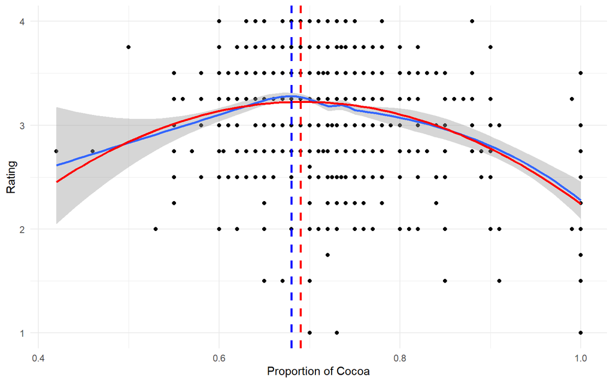

```r
# Polynomial Regression
Model1 <- lm(Rating ~ poly(CocoaPercent, 2), data = Chocolate)
Mod.Sum <- summary(Model1)

# Loess
Model2 <- loess(Rating ~ CocoaPercent, data = Chocolate)

ggplot(Chocolate, aes(CocoaPercent, Rating)) +
  geom_point() +
  geom_smooth(method = "loess", se = T) +
  stat_smooth(method="lm", se=TRUE, fill= NA,
                formula= y ~ poly(x, 2, raw=TRUE),colour="red") +
  geom_vline(xintercept = Chocolate$CocoaPercent[which.max(fitted(Model1))],
             linetype="dashed",
             color = "red", size=1) +
  geom_vline(xintercept = Chocolate$CocoaPercent[which.max(fitted(Model2))],
             linetype="dashed",
             color = "blue", size=1) +
  labs(x = "Proportion of Cocoa") +
  theme_minimal()
```

```r
# Min Max Scaling
Chocolate$RatingScaled <- (Chocolate$Rating - 1)/(4)

# Logistic Regression
Model3 <- glm(RatingScaled ~ poly(CocoaPercent, 2), data = Chocolate, family = binomial)
```

```r
knitr::kable(tidy(Model1))
```

| term | estimate | std.error | statistic | p.value |
| --- | --- | --- | --- | --- |
| (Intercept) | 3.184083 | 0.0091056 | 349.682515 | 0 |
| poly(CocoaPercent, 2)1 | -3.281171 | 0.4378289 | -7.494185 | 0 |
| poly(CocoaPercent, 2)2 | -4.321629 | 0.4378289 | -9.870589 | 0 |

## Summary

Originally, I thought that the data would have a better visually correlation, and I thought that there would be a purely linear relationship, however, the relationship between the proportion of cocoa and the rating seem parabolic in structure. In addition, the explanatory power is weaker because the R-Squared is 0.0623698 which means that the proportion of cocoa explain 6.2369805% of the variation in rating. This was not the result I was expecting as I naturally correlate a higher proportion of cocoa with a higher quality chocolate bar.

Another problem which should be addressed is that the data is continuous and bounded and a logistic regression was created to test out bounding the response variable by limiting the response variable to [0,1] interval through min-max standardization, however, given the shape of the data, the linear regression was more appropriate as the overall ratings of chocolate bars which approached 100% from 80% of cocoa percentage on average had a lower rating, most likely due to the strong bitterness of the pure cocoa bean leading to unbalanced flavors. This is not coherent with a logistic regression and it proved that it was not the valid model choice

# Section 3: Analysis of Bar Ingredients on Rating

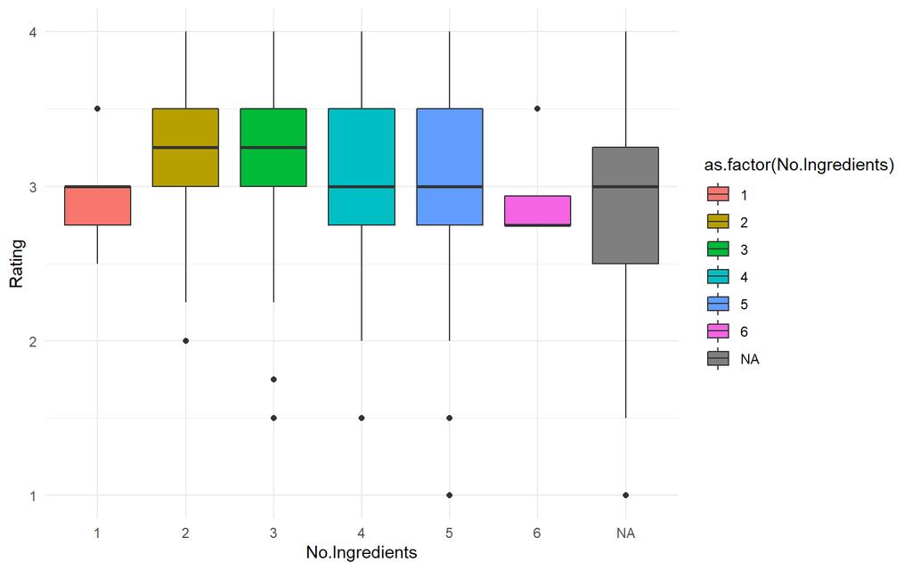

```r
Chocolate2 %>%
  ggplot(aes(No.Ingredients,
             Rating,
             fill = as.factor(No.Ingredients))) +
  geom_boxplot() +
  theme_minimal()
```

Based on the graph above, the number of ingredients used in the process to convert the cocoa into chocolate does not appear to have a significant difference between each other as the means are within the interquartile range (the boxes) for each of the factors.

## Visualization of Factors

### Sugar

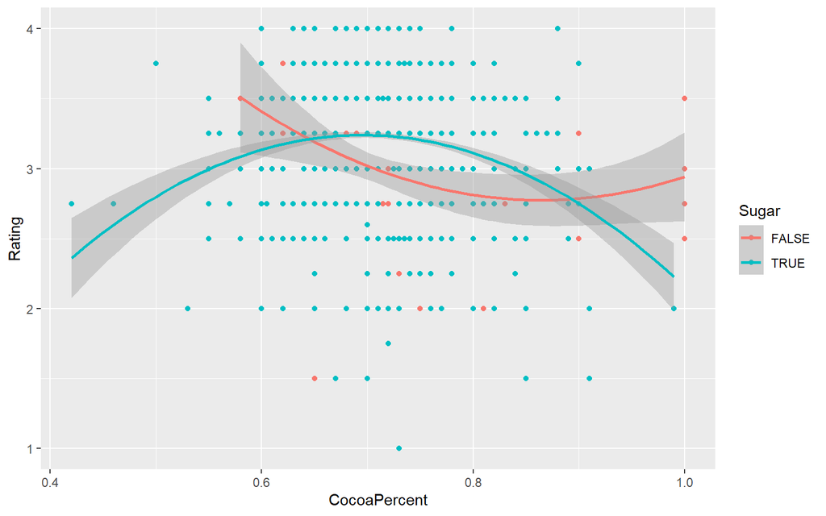

```r
Chocolate2 %>% filter(!is.na(Sugar)) %>%
ggplot(aes(x = CocoaPercent, y = Rating, color = Sugar)) +
  geom_point() +
  stat_smooth(method = "lm", formula = y ~ poly(x, 2))
```

### Sweetener

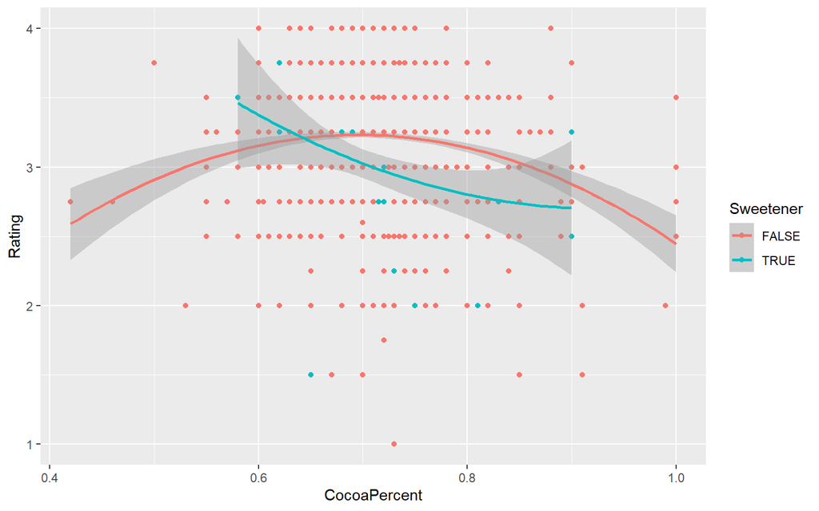

```r
Chocolate2 %>% filter(!is.na(Sweetener)) %>%
ggplot(aes(x = CocoaPercent, y = Rating, color = Sweetener)) +
  geom_point() +
  stat_smooth(method = "lm", formula = y ~ poly(x, 2))
```

### Cocoa Butter

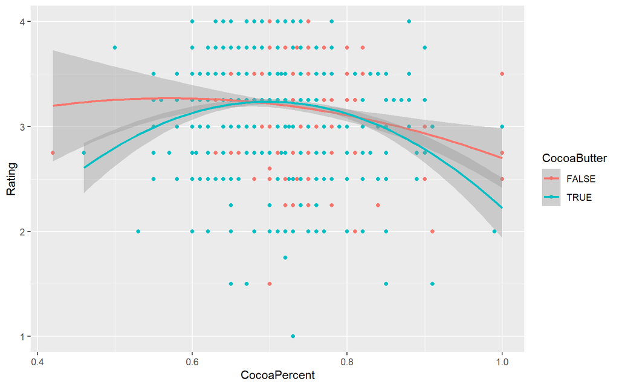

```r
Chocolate2 %>% filter(!is.na(CocoaButter)) %>%
ggplot(aes(x = CocoaPercent, y = Rating, color = CocoaButter)) +
  geom_point() +
  stat_smooth(method = "lm", formula = y ~ poly(x, 2))
```

### Vanilla

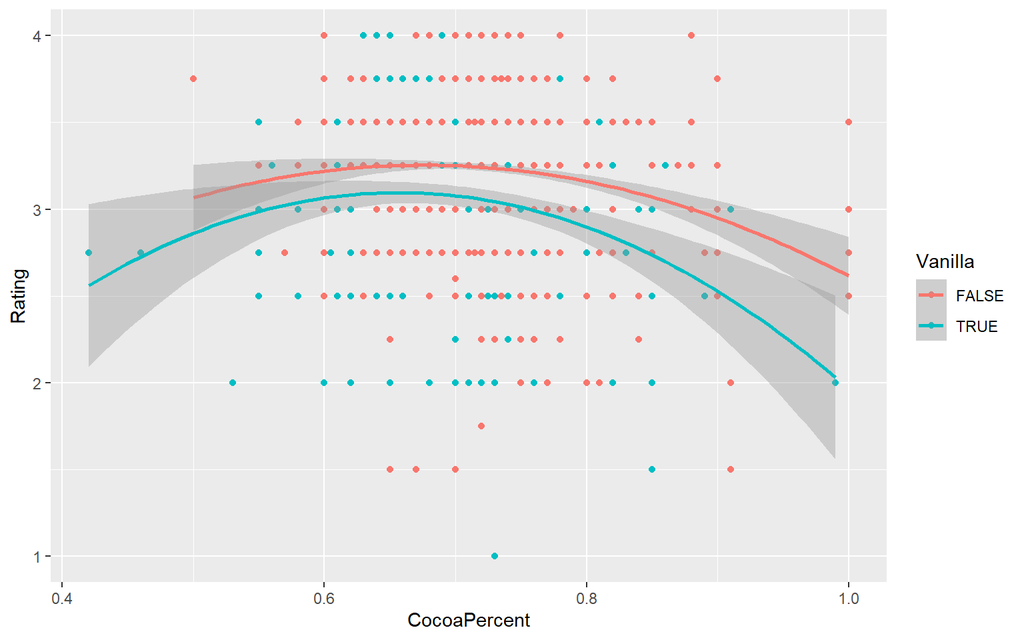

```r
Chocolate2 %>% filter(!is.na(Vanilla)) %>%
ggplot(aes(x = CocoaPercent, y = Rating, color = Vanilla)) +
  geom_point() +
  stat_smooth(method = "lm", formula = y ~ poly(x, 2))
```

## Linear Model

```r
formula = Rating ~ 0 + poly(CocoaPercent,2) + Sugar + Sweetener + Vanilla + CocoaButter + Lecithin

CModel1 <- lm(formula, Chocolate2)
sum.CMod <- summary(CModel1)
Ingred.ModelData <- tidy(CModel1)
Ingred.ModelData$Sig.1 <- ifelse(Ingred.ModelData$p.value < .1, TRUE, FALSE)
Ingred.ModelData$Sig.05 <- ifelse(Ingred.ModelData$p.value < .05, TRUE, FALSE)
Ingred.ModelData$Sig.01 <- ifelse(Ingred.ModelData$p.value < .01, TRUE, FALSE)
knitr::kable(Ingred.ModelData)
```

| term | estimate | std.error | statistic | p.value | Sig.1 | Sig.05 | Sig.01 |
| --- | --- | --- | --- | --- | --- | --- | --- |
| poly(CocoaPercent, 2)1 | -3.6683273 | 0.5500256 | -6.669376 | 0.0000000 | TRUE | TRUE | TRUE |
| poly(CocoaPercent, 2)2 | -3.7757552 | 0.6442920 | -5.860316 | 0.0000000 | TRUE | TRUE | TRUE |
| SugarFALSE | 3.8554473 | 0.2129259 | 18.106991 | 0.0000000 | TRUE | TRUE | TRUE |
| SugarTRUE | 3.1971503 | 0.0165187 | 193.547401 | 0.0000000 | TRUE | TRUE | TRUE |
| SweetenerTRUE | -0.8636126 | 0.2189605 | -3.944148 | 0.0000826 | TRUE | TRUE | TRUE |
| VanillaTRUE | -0.1891821 | 0.0270886 | -6.983819 | 0.0000000 | TRUE | TRUE | TRUE |
| CocoaButterTRUE | 0.0545321 | 0.0206785 | 2.637140 | 0.0084193 | TRUE | TRUE | TRUE |
| LecithinTRUE | -0.0341942 | 0.0243025 | -1.407024 | 0.1595604 | FALSE | FALSE | FALSE |